# 4 Goodness of Fit

Assessment data are generally imperfect and require sophisticated statistical methods to deal with the various issues they present. Cubic B-spline basis functions are used in the calculation of SGPs to more adequately model the heteroscedasticity, non-linearity and skewness. Despite this, assumptions that are made in the statistical modeling process can impact how well the percentile curves fit the data.[^4] Accordingly a thorough evaluation of the models’ fit is always required.

Examination of the Colorado Student Growth Model goodness-of-fit was conducted by first inspecting model fit plots the `SGP` software package produced for each analysis, and subsequently inspecting student level correlations between growth and achievement. Discussion of the model fit plots in general and examples of them are provided below, as are tables of the correlation results. The complete portfolio of model fit plots is provided in Appendix A.

## 4.1 Model Fit Plots

Using all available PARCC, CMAS and PSAT/SAT scores as the variables, estimation of student growth percentiles was conducted for each possible student (those with a current score and at least one prior score). Each analysis is defined by the grade and content area for the grade-level analyses and exact content area (and grade when relevant) sequences for the PSAT/SAT subjects. A goodness of fit plot is produced for each unique analysis run in 2018 and are all provided in Appendix A to this report.

As an example, Figure 1 shows the results for 5<sup>th</sup> grade ELA as an example of good model fit. Figure 2 is an example of minor model misfit from the PSAT 9 Mathematics analysis that uses Geometry as the most recent prior.

The “Ceiling/Floor Effects Test” panel is intended to help identify potential problems in SGP estimation at the Highest and Lowest Obtainable (or Observed) Scale Scores (HOSS and LOSS). Most often these effects are caused when it is relatively typical for extremely high (low) achieving students to consistently score at or near the HOSS (LOSS) each year leading to the SGPs for these students to be unexpectedly low (high). That is, for example, if a sufficient number of students maintain performance at the HOSS over time, this performance will be estimated as typical, and therefore SGP estimates will reflect typical growth (e.g. 50th percentile). In some cases small deviations from these extreme score values might even yield low growth estimates. Although these score patterns can legitimately be estimated as a typical or low percentile, it is potentially an unfair description of actual student growth (and by proxy teacher or school, etc. performance metrics that use them). Ultimately this is usually an artifact of the assessments’ inability to adequately measure student performance at extreme ability levels.

The table of values here shows whether the current year scale scores at both extremes yield the expected SGPs[^5]. The expectation is that the majority of SGPs for students scoring at or near the LOSS will be low (preferably less than 5 and not higher than 10), and that SGPs for students scoring at or near the HOSS will be high (preferably higher than 95 and not less than 90). Because few students may score *exactly* at the HOSS/LOSS, the top/bottom 50 students are selected and any student scoring within their range of scores are selected for inclusion in these tables. Consequently, there may be a range of scores at the HOSS/LOSS rather than a single score, and there may be more than 50 students included in the HOSS/LOSS row if the 50 students at the extremes only contain the single HOSS/LOSS score.

This table is meant to serve more as a “canary in the coal mine” than as a detailed, conclusive indicator of ceiling or floor effects, and a more fine grained analysis that considers the relationship between score histories and SGPs may be necessary. Appendix C of this report provides a more in depth investigation.

The two bottom panels compare the observed conditional density of the SGP estimates with the theoretical (uniform) density. The bottom left panel shows the empirical distribution of SGPs given prior scale score deciles in the form of a 10 by 10 cell grid. Percentages of student growth percentiles between the 10<sup>th</sup>, 20<sup>th</sup>, 30<sup>th</sup>, 40<sup>th</sup>, 50<sup>th</sup>, 60<sup>th</sup>, 70<sup>th</sup>, 80<sup>th</sup>, and 90<sup>th</sup> percentiles were calculated based upon the empirical decile of the cohort’s prior year scaled score distribution[^6]. With an infinite population of test takers, at each prior scaled score, with perfect model fit, the expectation is to have 10 percent of the estimated growth percentiles between 1 and 9, 10 and 19, 20 and 29, …, and 90 and 99. Deviations from 10 percent, indicated by red and blue shading, suggests lack of model fit. The further *above* 10 the darker the red, and the further *below* 10 the darker the blue.

When large deviations occur, one likely cause is a clustering of scale scores that makes it impossible to “split” the score at a dividing point forcing a majority of the scores into an adjacent cell. This occurs more often in lowest grade levels where fewer prior scores are available (particularly in the lowest grade when only a single prior is available). Another common cause of this is small cohort size (e.g. fewer than 5,000 students).

The bottom right panel of each plot is a Q-Q plot which compares the observed distribution of SGPs with the theoretical (uniform) distribution. An ideal plot here will show black step function lines that do not deviate greatly from the ideal, red line which traces the 45 degree angle of perfect fit.

### 4.1.1 Examples of model fit

We provide two examples here of cohort-referenced model fit. Overall the 2018 CMAS and PSAT/SAT results in all subjects are excellent with few exceptions. See Appendix A for all goodness of fit plots.

Figure 1 shows the results for 5<sup>th</sup> grade ELA as an example of good model fit.

**Figure 1:** Goodness of Fit Plot for 2018 5<sup>th</sup> Grade ELA: Example of good model fit.

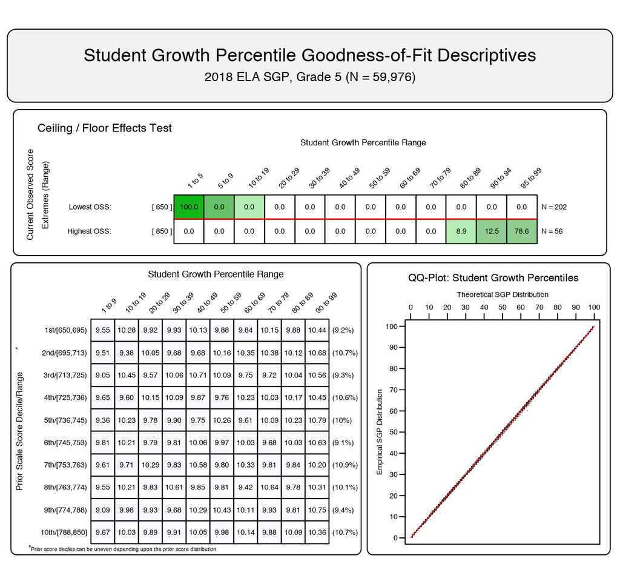

Minor misfit in the PSAT 9 Mathematics model is likely due in large part to the relatively small cohort size (2,000+ kids). This cohort is a relatively homogenous cohort of high academic achievers compared to others (more than 80% meeting or exceeding proficiency in Geometry). The indication of a ceiling effect in this plot is a potential concern here as well, likely again due to the cohort’s high achievement status resulting in a higher frequency of perfect scores on both prior and current assessments. These results are examined in greater detail in Appendix C of this report.

**Figure 2:** Goodness of Fit Plot for a 2018 Geometry Progression: Example of slight model mis-fit.

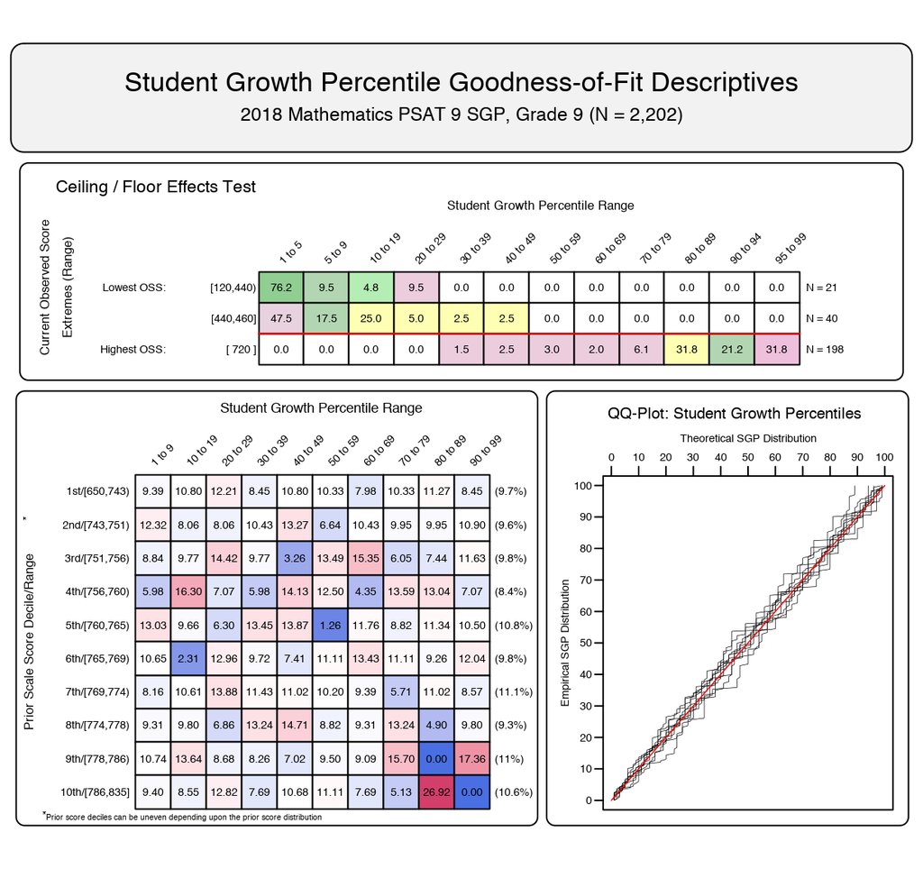

## 4.2 Growth and Prior Achievement at the Student Level

To investigate the possibility that individual level misfit might impact summary level results, student level SGP results were examined relative to prior achievement. With perfect fit to data, the correlation between students’ most recent prior achievement scores and their student growth percentiles is zero (i.e., the goodness of fit tables would have a uniform distribution of percentiles across all previous scale score levels). To investigate in another way, correlations between **a)** prior and current scale scores (achievement) and **b)** prior score and student growth percentiles were calculated. Evidence of good model fit begins with a strong positive relationship between prior and current achievement, which suggests that growth is detectable and modeling it is reasonable to begin with. A lack of relationship (zero correlation) between prior achievement and growth confirms that the model has fit the data well and produced a uniform distribution of percentiles across all previous scale score levels.

Student-level correlations for grade-level CMAS subjects are presented in Table 3, and the results are generally as expected. Strong relationships exist between prior and current scale scores for the grade level analyses (column 3). The correlation between students’ most recent prior achievement scores and their student growth percentiles is zero when the model is perfectly fit to the data. This also indicates that students can demonstrate high (or low) growth regardless of prior achievement.

### 4.2.1 Grade-level CMAS subjects

| **Table 3:** CMAS Student Level Correlations between Prior Standardized Scale Score and 1) Current Scale Score and 2) SGP. Content Area | **Table 3:** CMAS Student Level Correlations between Prior Standardized Scale Score and 1) Current Scale Score and 2) SGP. Grade | **Table 3:** CMAS Student Level Correlations between Prior Standardized Scale Score and 1) Current Scale Score and 2) SGP. | **Table 3:** CMAS Student Level Correlations between Prior Standardized Scale Score and 1) Current Scale Score and 2) SGP. | **Table 3:** CMAS Student Level Correlations between Prior Standardized Scale Score and 1) Current Scale Score and 2) SGP. N Size |
| --- | --- | --- | --- | --- |
| ELA | 4 | 0.83 | 0.00 | 59,469 |
|  | 5 | 0.81 | 0.00 | 59,976 |
|  | 6 | 0.81 | 0.00 | 58,201 |
|  | 7 | 0.83 | 0.00 | 55,423 |
|  | 8 | 0.83 | 0.00 | 52,761 |
| Mathematics | 4 | 0.85 | 0.00 | 61,206 |
|  | 5 | 0.85 | 0.00 | 60,818 |
|  | 6 | 0.85 | 0.00 | 58,262 |
|  | 7 | 0.85 | 0.00 | 54,569 |
|  | 8 | 0.82 | 0.00 | 43,294 |

### 4.2.2 PSAT/SAT Subjects

| **Table 4:** PSAT/SAT Student Level Correlations between Prior Standardized Scale Score and 1) Current Scale Score and 2) SGP - Disaggregated by Norm Group. Content Area | **Table 4:** PSAT/SAT Student Level Correlations between Prior Standardized Scale Score and 1) Current Scale Score and 2) SGP - Disaggregated by Norm Group. Most Recent Prior | **Table 4:** PSAT/SAT Student Level Correlations between Prior Standardized Scale Score and 1) Current Scale Score and 2) SGP - Disaggregated by Norm Group. | **Table 4:** PSAT/SAT Student Level Correlations between Prior Standardized Scale Score and 1) Current Scale Score and 2) SGP - Disaggregated by Norm Group. | **Table 4:** PSAT/SAT Student Level Correlations between Prior Standardized Scale Score and 1) Current Scale Score and 2) SGP - Disaggregated by Norm Group. N Size |
| --- | --- | --- | --- | --- |
| ELA PSAT 9 | 2017 ELA Grade 8 | 0.77 | 0.00 | 50,794 |
| ELA PSAT 10 | 2017 ELA 9 | 0.78 | 0.01 | 44,448 |
| ELA SAT | 2017 ELA PSAT 10 | 0.87 | -0.01 | 51,881 |
| Mathematics PSAT 9 | 2017 Algebra I | 0.77 | 0.05 | 8,947 |
|  | 2017 Geometry | 0.68 | 0.00 | 2,202 |
|  | 2017 Math Grade 8 | 0.78 | 0.00 | 38,506 |
| Mathematics PSAT 10 | 2017 Algebra I | 0.71 | 0.01 | 25,187 |
|  | 2017 Geometry | 0.75 | 0.01 | 7,968 |
|  | 2017 Integrated Math 1 | 0.80 | 0.00 | 7,390 |
| Mathematics SAT | 2017 Math PSAT 10 | 0.68 | -0.01 | 51,881 |

# 5 SGP Results

Growth percentiles, being quantities associated with each individual student, can be easily summarized across numerous grouping indicators to provide summary results regarding growth. The median and mean of a collection of growth percentiles are used as measures of central tendency that summarize the distribution as a single number. With perfect data fit, we expect the state median of all student growth percentiles in any grade to be 50 because the data are norm-referenced across all students in the state. Median (and mean) growth percentiles well below 50 represent growth less than the state “average” and median growth percentiles well above 50 represent growth in excess of the state “average”.

To demonstrate the norm-referenced nature of the growth percentiles viewed at the state level, Tables 5 and 6 present the cohort-referenced growth percentile medians and means for the CMAS and PSAT/SAT content areas respectively.

| **Table 5:** 2018 CMAS Median (Mean) Student Growth Percentile by Grade and Content Area. Content Area | **Table 5:** 2018 CMAS Median (Mean) Student Growth Percentile by Grade and Content Area. | **Table 5:** 2018 CMAS Median (Mean) Student Growth Percentile by Grade and Content Area. Grades 4 | **Table 5:** 2018 CMAS Median (Mean) Student Growth Percentile by Grade and Content Area. Grades 5 | **Table 5:** 2018 CMAS Median (Mean) Student Growth Percentile by Grade and Content Area. Grades 6 | **Table 5:** 2018 CMAS Median (Mean) Student Growth Percentile by Grade and Content Area. Grades 7 | **Table 5:** 2018 CMAS Median (Mean) Student Growth Percentile by Grade and Content Area. Grades 8 |
| --- | --- | --- | --- | --- | --- | --- |
| ELA |  | 50 (49.9) | 50 (50) | 50 (50.1) | 50 (50) | 50 (49.9) |
| Mathematics |  | 50 (49.9) | 50 (50) | 50 (50) | 50 (50.1) | 50 (49.9) |

| **Table 6:** 2018 PSAT/SAT Median and Mean Student Growth Percentile by Content Area. Content Area | **Table 6:** 2018 PSAT/SAT Median and Mean Student Growth Percentile by Content Area. Median SGP | **Table 6:** 2018 PSAT/SAT Median and Mean Student Growth Percentile by Content Area. Mean SGP |
| --- | --- | --- |
| Ela PSAT 9 | 51 | 50.4 |
| Ela PSAT 10 | 51 | 50.6 |
| Ela SAT | 50 | 50.2 |
| Mathematics PSAT 9 | 50 | 50.0 |
| Mathematics PSAT 10 | 50 | 50.1 |
| Mathematics SAT | 50 | 50.3 |

Based upon perfect model fit to the data, the median of all state growth percentiles in each grade by year by subject combination should be 50. That is, in the conditional distributions, 50 percent of growth percentiles should be less than 50 and 50 percent should be greater than 50. Deviations from 50 indicate imperfect model fit to the data. Imperfect model fit can occur for a number of reasons, including issues with the data (e.g., floor and ceiling effects leading to a “bunching” up of the data) or how the SGP function fits the data. PSAT/SAT results are further complicated by aggregating across multiple analyses (prior course patterns). The results in Tables 5 and 6 are nearly perfect, with almost all values equal to 50.

The results are coarse in that they are aggregated across tens of thousands of students. More refined fit analyses were presented in the Goodness-of-Fit section. Depending upon feedback from CDE, it may be desirable to tweak some operational parameters and attempt to improve fit even further. The impact upon the operational results based on better fit is expected to be extremely minor.

It is important to note how, at the entire state level, the *norm-referenced* growth information returns little information on annual trends due to its norm-reference nature. What the results indicate is that a typical (or average) student in the state demonstrates 50<sup>th</sup> percentile growth. That is, “typical students” demonstrate “typical growth”. One benefit of the norm-referenced results follows when subgroups are examined (e.g., schools, district, demographic groups, etc.) Examining subgroups in terms of the mean or median of their student growth percentiles, it is then possible to investigate why some subgroups display lower/higher student growth than others. Moreover, because the subgroup summary statistic (i.e., the median) is composed of many individual student growth percentiles, one can break out the result and further examine the distribution of individual results.

## 5.1 Group Level Results

Unlike reporting SGPs at the individual level, when aggregating to the group level (e.g., school) the correlation between aggregate prior student achievement and aggregate growth is rarely zero. The correlation between prior student achievement and growth at the school level is a compelling descriptive statistic because it indicates whether students attending schools serving higher achieving students grow faster (on average) than those students attending schools serving lower achieving students. Results from previous state analyses show a correlation between prior achievement of students associated with a current school (quantified as percent at/above proficient) and the median SGP are typically between 0.1 and 0.3 (although higher numbers have been observed in some states as well). That is, these results indicate that on average, students attending schools serving lower achieving students tend to demonstrate less exemplary growth than those attending schools serving higher achieving students. Equivalently, based upon ordinary least squares (OLS) regression assumptions, the prior achievement level of students attending a school accounts for between 1 and 10 percent of the variability observed in student growth. There are no definitive numbers on what this correlation should be, but recent studies on value-added models show similar results (McCaffrey, Han, & Lockwood, 2008).

### 5.1.1 School Level Results

To illustrate these relationships visually, the bubble charts in Figures 3 and 4 depict growth as quantified by the median SGP of students at the school against prior achievement status, quantified by percentage of student at/above proficient at the school. “Prior Percent at/above Proficient” in this case is determined by the percent of student’s that scored in the “Level 4” or “Level 5” range of the prior year’s PARCC test out of all student’s that received a score. The charts have been successful in helping to motivate the discussion of the two qualities: student achievement and student growth. Though the figures are not detailed enough to indicate strength of relationship between growth and achievement, they are suggestive and valuable for discussions with stakeholders who are being introduced to the growth model for the first time. Only charts for the CMAS subjects are shown here.

**Figure 3:** School-level Bubble Plots for Colorado: ELA, 2017-2018.

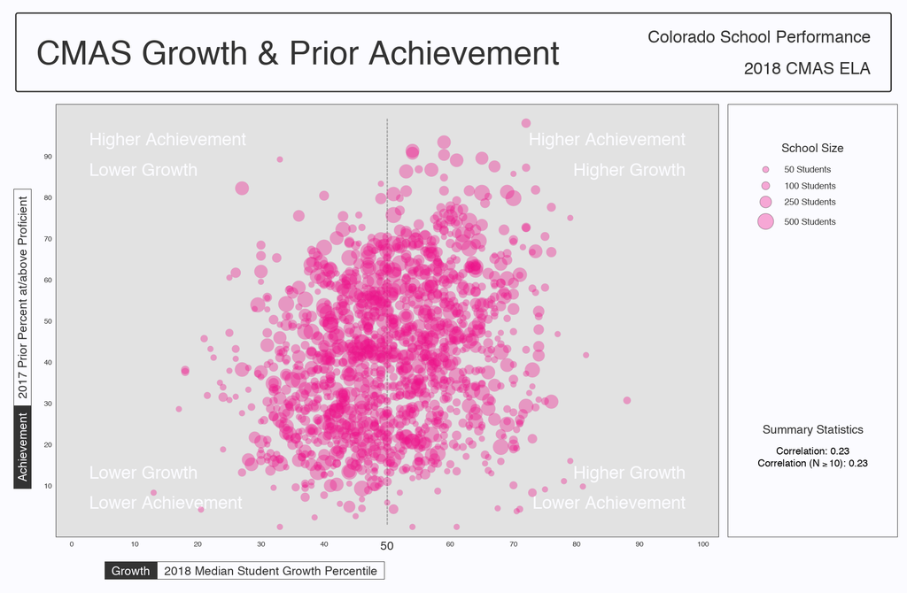

**Figure 4:** School-level Bubble Plots for Colorado: Mathematics, 2017-2018.

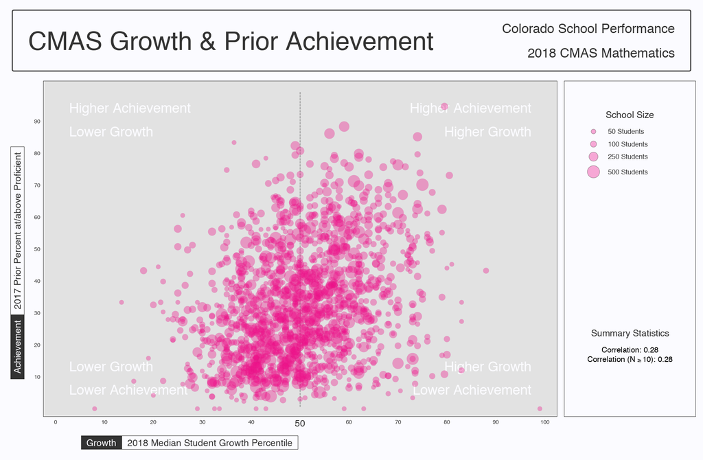

**Table 7:** Correlations between Mean Prior Standardized Scale Score and Aggregate SGPs - (Combined Subjects)

| Year | Median SGP | Mean SGP |
| --- | --- | --- |
| 2016 | 0.33 | 0.35 |
| 2017 | 0.36 | 0.38 |
| 2018 | 0.36 | 0.38 |

Correlation tables describing the relationship between prior standardized scale score and aggregate growth percentiles are presented below in separate subsections for CMAS and PSAT/SAT subjects. The first correlation table in the each subsection provides these overall SGP aggregates’ relationships with mean prior standardized scale scores. The additional correlation tables are disaggregated by content area, and content area and grade to provide more detail.

**CMAS Content Areas**

| **Table 8:** School Level CMAS Correlations between Mean Prior Standardized Scale Score and Aggregate SGPs by Content Area. Content Area | **Table 8:** School Level CMAS Correlations between Mean Prior Standardized Scale Score and Aggregate SGPs by Content Area. Year | **Table 8:** School Level CMAS Correlations between Mean Prior Standardized Scale Score and Aggregate SGPs by Content Area. Median SGP | **Table 8:** School Level CMAS Correlations between Mean Prior Standardized Scale Score and Aggregate SGPs by Content Area. Mean SGP |
| --- | --- | --- | --- |
| ELA | 2016 | 0.25 | 0.27 |
|  | 2017 | 0.23 | 0.24 |
|  | 2018 | 0.27 | 0.29 |
| Mathematics | 2016 | 0.32 | 0.35 |
|  | 2017 | 0.32 | 0.33 |
|  | 2018 | 0.33 | 0.34 |

| **Table 9:** 2018 School Level CMAS Correlations between Mean Prior Standardized Scale Score and Aggregate SGPs by Content Area and Grade. Content Area | **Table 9:** 2018 School Level CMAS Correlations between Mean Prior Standardized Scale Score and Aggregate SGPs by Content Area and Grade. Grade | **Table 9:** 2018 School Level CMAS Correlations between Mean Prior Standardized Scale Score and Aggregate SGPs by Content Area and Grade. Median SGP | **Table 9:** 2018 School Level CMAS Correlations between Mean Prior Standardized Scale Score and Aggregate SGPs by Content Area and Grade. Mean SGP |
| --- | --- | --- | --- |
| ELA | 4 | 0.16 | 0.15 |
|  | 5 | 0.12 | 0.12 |
|  | 6 | 0.15 | 0.16 |
|  | 7 | 0.10 | 0.11 |
|  | 8 | 0.16 | 0.18 |
| Mathematics | 4 | 0.12 | 0.13 |
|  | 5 | 0.11 | 0.11 |
|  | 6 | 0.18 | 0.20 |
|  | 7 | 0.23 | 0.25 |
|  | 8 | 0.30 | 0.33 |

**PSAT/SAT Subjects**

| **Table 10:** School Level PSAT/SAT Correlations between Mean Prior Standardized Scale Score and Aggregate SGPs by Content Area. Content Area | **Table 10:** School Level PSAT/SAT Correlations between Mean Prior Standardized Scale Score and Aggregate SGPs by Content Area. Year | **Table 10:** School Level PSAT/SAT Correlations between Mean Prior Standardized Scale Score and Aggregate SGPs by Content Area. Median SGP | **Table 10:** School Level PSAT/SAT Correlations between Mean Prior Standardized Scale Score and Aggregate SGPs by Content Area. Mean SGP |
| --- | --- | --- | --- |
| ELA PSAT 9 | 2018 | 0.21 | 0.23 |
| ELA PSAT 10 | 2017 | 0.29 | 0.30 |
|  | 2018 | 0.29 | 0.30 |
| ELA SAT | 2017 | 0.40 | 0.44 |
|  | 2018 | 0.50 | 0.53 |
| Mathematics PSAT 9 | 2018 | 0.36 | 0.38 |
| Mathematics PSAT 10 | 2017 | 0.39 | 0.40 |
|  | 2018 | 0.39 | 0.41 |
| Mathematics SAT | 2017 | 0.58 | 0.63 |
|  | 2018 | 0.47 | 0.52 |

# References

Betebenner, D. W. (2009). Norm- and criterion-referenced student growth. *Educational Measurement: Issues and Practice*, *28*(4), 42–51.

Betebenner, D. W., VanIwaarden, A., Domingue, B., & Shang, Y. (2018). *SGP: Student growth percentiles & percentile growth trajectories.* Retrieved from sgp.io

Chernozhukov, V., Fernández-Val, I., & Galichon, A. (2010). Quantile and probability curves without crossing. *Econometrica*, *78*(3), 1093–1125. Wiley Online Library.

Koenker, R. (2005). *Quantile regression*. Cambridge: Cambridge University Press.

McCaffrey, D., Han, B., & Lockwood, J. (2008). From data to bonuses: A case study of the issues related to awarding teachers pay on the basis of their students’ progress. In *Performance incentives: Their growing impact on american k-12 education (conference)*. Vanderbilt University, Nashville, TN: National Center for Performance Incentives.

R Development Core Team. (2017). *R: A language and environment for statistical computing*. Vienna, Austria: R Foundation for Statistical Computing. Retrieved from http://www.R-project.org

[^1]: More in-depth treatment of the SGP Methodology can be found [here](https://github.com/CenterForAssessment/SGP_Resources/tree/master/articles) and in Appendix B of this report.
[^2]: This does not represent the number of SGPs produced, however, because students are required to have at least one prior score available as well.
[^3]: It should be noted that the independent estimation of the regression functions can potentially result in the crossing of the quantile functions. This occurs near the extremes of the distributions and is more likely to occur given the use of non-linear functions. A potential result of allowing the quantile functions to cross would be *lower* percentile estimations of growth for *higher* observed scale scores at the extremes (give all else equal in prior scores) and vice versa. In order to deal with these contradictory estimates, quantile regression results are isotonized to prevent quantile crossing following the methods derived by Chernozhukov, Fernandez-Val and Glichon (2010).
[^4]: Independent estimation of the regression functions can potentially result in the crossing of the quantile functions. This occurs near the extremes of the distributions and is more likely to occur given the use of non-linear functions. A potential result of allowing the quantile functions to cross would be *lower* estimated growth percentiles for *higher* observed scale scores at the extremes (give all else equal in prior scores) and vice versa. Quantile regression results are isotonized to prevent these contradictory estimates from quantile crossing following the methods derived by Chernozhukov, Fernandez-Val and Glichon (2010).
[^5]: Note that the prior year scale scores are not represented here, but are also a critical factor in ceiling effects.
[^6]: The total students in each analysis varies depending on grade and subject, and prior score deciles are based only on scores for students used in the SGP calculations.